# Datos Salud

ronny hdez-mora & Erick Calderón Morales

01 marzo, 2019

# Comunicación con el API

En primer lugar para traer los datos que el Gobierno de Costa Rica tiene disponibles y abiertos, tenemos que seguir una serie de pasos en nuestra sesión. La que presentamos acá no es la única manera de hacerlo, pero tratamos de presentar un paso a paso que nos lleve a identificar fácilmente los conjuntos de datos existentes y cómo tener un vistazo rápido de las dimensiones.

## Credenciales

Uno de los primeros paso es que debemos de crear como objetos las credenciales para poder comunicarnos con el API de datos abiertos del Gobierno de CR.

```r
url_base <- "http://api.datosabiertos.presidencia.go.cr/api/v2/datastreams/"
api_key <- "a5fff4275119df5926a807941576f6cad95cf84f"
```

## Revisar cuales conjuntos de datos existen

```r
indice <- get_index(url_base, api_key = api_key)

guid <- indice %>%
  select(title, guid)

dimensiones <- get_dimensions(base_url = url_base, api_key = api_key)
```

```
## Error in dataset[1, ] : incorrect number of dimensions
```

```r
dimensiones <- left_join(dimensiones, guid, by = c("GUID" = "guid"))

dim_ordenado <- dimensiones %>%
    arrange(desc(DIM)) %>%
  kable() %>%
  kable_styling("striped", full_width = F)

dim_ordenado
```

| GUID | NROW | NCOL | DIM | title |
| --- | --- | --- | --- | --- |
| EJECU-DE-PRESU-DE-50724 | 999 | 40 | 39960 | Ejecución de presupuesto de Instituciones para el 2014 |
| EJECU-DE-PRESU-DE-INSTI | 999 | 39 | 38961 | Ejecución de presupuesto de Instituciones para el 2015 |
| BASE-DE-DATOS-RNT | 999 | 20 | 19980 | Base de datos RNT |
| OCTUB-2016-SALAR-MINIS-DE | 999 | 18 | 17982 | Octubre 2016 - Salarios Ministerio de la Presidencia |
| MINIS-DE-SEGUR-PUBLI-40332 | 999 | 15 | 14985 | MINISTERIO DE SEGURIDAD PÚBLICA |
| MINIS-DE-OBRAS-PUBLI-71448 | 999 | 15 | 14985 | MINISTERIO DE OBRAS PUBLICAS Y TRANSPORTES |
| MINIS-DE-EDUCA-PUBLI | 999 | 15 | 14985 | MINISTERIO DE EDUCACIÓN PÚBLICA |
| MINIS-DE-EDUCA-PUBLI-2018 | 999 | 15 | 14985 | Ministerio de Educación Pública - 2018 |
| MINIS-DE-OBRAS-PUBLI-48620 | 999 | 15 | 14985 | Ministerio de Obras Públicas y Transporte - 2018 |
| MINIS-DE-OBRAS-PUBLI-71783 | 999 | 15 | 14985 | Ministerio de Obras Públicas y Transportes 2014-2017 |
| MINIS-DE-OBRAS-PUBLI-97637 | 999 | 15 | 14985 | Ministerio de Obras Públicas y Transporte (2014-2016) |
| MINIS-DE-SEGUR-PUBLI-56312 | 999 | 14 | 13986 | MINISTERIO DE SEGURIDAD PÚBLICA |
| MINIS-DE-SEGUR-PUBLI-2018 | 899 | 15 | 13485 | Ministerio de Seguridad Pública - 2018 |
| ABRIL-2016-SALAR-PRESI-DE | 999 | 13 | 12987 | Abril 2016 - Salarios Presidencia de la República |
| PLANI-DE-SALAR-PRESI-DE | 999 | 13 | 12987 | Abril 2016: Planilla de Salarios Presidencia de la República |
| MINIS-DE-EDUCA-PUBLI-59938 | 808 | 15 | 12120 | Ministerio de Educación Pública 2014-2017 |
| MINIS-DE-EDUCA-PUBLI-67848 | 808 | 15 | 12120 | Ministerio de Educación Pública (2014-2016) |
| MINIS-DE-EDUCA-PUBLI-93512 | 808 | 15 | 12120 | Ministerio de Educación Pública (2014-2016) |
| SERVI-FITOS-DEL-ESTAD | 708 | 15 | 10620 | SERVICIO FITOSANITARIO DEL ESTADO |
| MINIS-DE-EDUCA-PUBLI-2014 | 675 | 15 | 10125 | Ministerio de Educación Pública (2014-2016) |
| AYA-SALAR-ENERO-2016 | 999 | 10 | 9990 | AYA - Salarios Enero 2016 |
| DATOS-CORRE-AL-PAGO-DE | 999 | 10 | 9990 | Octubre 2015: Planilla de Salarios: Presidencia de la República |
| MINIS-DE-SEGUR-PUBLI | 620 | 15 | 9300 | Ministerio de Seguridad Pública |
| MINIS-DE-SEGUR-PUBLI-58601 | 620 | 15 | 9300 | Ministerio de Seguridad Pública 2014-2017 |
| MINIS-DE-SEGUR-PUBLI-2014 | 620 | 15 | 9300 | Ministerio de Seguridad Pública (2014-2016) |
| MINIS-DE-OBRAS-PUBLI-Y | 614 | 15 | 9210 | Ministerio de Obras Públicas y Transportes (2015) |
| SERVI-FITOS-DEL-ESTAD-2017 | 535 | 15 | 8025 | Servicio Fitosanitario del Estado - 2017 |
| SERVI-FITOS-DEL-ESTAD-2018 | 535 | 15 | 8025 | Servicio Fitosanitario del Estado - 2018 |
| ABRIL-2016-SALAR-MINIS-DE | 999 | 8 | 7992 | Abril 2016 - Salarios Ministerio de la Presidencia |
| ABRIL-2016-SALAR-DEL-MINIS | 999 | 8 | 7992 | Abril 2016 - Salarios del Ministerio de la Presidencia |

[output cut: 394 more lines]

## Traer conjunto de datos de salud

Una vez identificado el conjunto de datos podemos anotar el GUID y con este hacer el llamado específico. En nuestro caso estamos interesados en el conjunto de datos **Base de datos RNT** y cuyo GUID es **BASE-DE-DATOS-RNT**

```r
# Anotar en un objeto el GUID de la tabla que nos interesa
guid_tabla <- "BASE-DE-DATOS-RNT"

# Llamar la tabla. Usamos las mismas credenciales que habíamos usado
salud <- get_data(base_url = url_base, api_key = api_key,
                            guid = guid_tabla)
```

# **Exploración de datos de salud**

En primer lugar hay que limpiar un poco el conjunto de datos, renombrar las variables, coercionar la columna de fechas

```r
# TODO: fecha diagnostico esta en diferentes formatos
salud <- clean_names(salud) %>%
  mutate(fecha_diagnostico = ymd(fecha_diagnostico)) %>%
  mutate(fecha_registro = dmy(fecha_registro))
```

## **Tumores más comunes en el conjunto de datos**

Una vez que tenemos los datos podemos hacer exploraciones donde agrupamos las observaciones por alguna categoría, en este caso de la columna **descrip_dx_clinico** y el total de casos que existen:

```r
# Ver cuales son los tumores mas comunes:
tumores_comunes <- salud %>%
  group_by(descrip_dx_clinico) %>%
  summarise(
    total = n()
  ) %>%
  arrange(desc(total)) %>%
  slice(1:10) %>%
  kable() %>%
  kable_styling("striped", full_width = F)

tumores_comunes
```

| descrip_dx_clinico | total |
| --- | --- |
| Tumor maligno de la piel de otras partes y de las no especificadas de | 155 |
| Tumor maligno de la mama, parte no especificada | 118 |
| Tumor maligno de la próstata | 82 |
| Tumor maligno de la glándula tiroides | 61 |
| Tumor maligno del estómago, parte no especificada | 37 |
| Tumor maligno del cuello del útero, sin otra especificación | 33 |
| Tumor maligno del recto | 25 |
| Tumor maligno del colon, parte no especificada | 24 |
| Tumor maligno del endometrio | 24 |
| Tumor maligno de la piel del miembro superior, incluido el hombro | 23 |

## **Tumores más comunes por provincia de Costa Rica**

Ahora bien, ya que tenemos cuáles son los tumores más comunes en el conjunto de datos, podríamos filtrar los diez primeros para visualizar los casos totales por provincia separado por el sexo

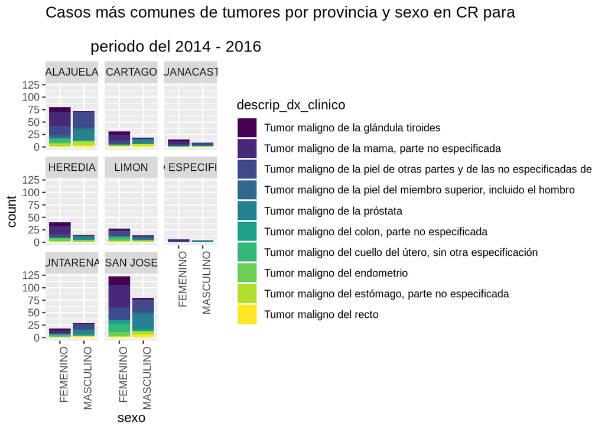

```r
# Tumores comunes por provincia
tumores_comunes <- salud %>%
  group_by(descrip_dx_clinico) %>%
  summarise(
    total = n()
  ) %>%
  arrange(desc(total)) %>%
  slice(1:10)

salud %>%
  inner_join(y = tumores_comunes, by = "descrip_dx_clinico") %>%
  ggplot(aes(x = sexo, fill = descrip_dx_clinico)) +
  geom_bar() +
  facet_wrap(~provincia) +
  scale_fill_viridis_d() +
  theme(axis.text.x = element_text(angle = 90, hjust = 1)) +
  # theme_bw() +
  ggtitle("Casos más comunes de tumores por provincia y sexo en CR para \n
          periodo del 2014 - 2016")
```

## **Proporción de sexos por hospital**

Los 20 hospitales con mayor número de casos han sido seleccionados y con estos hemos revisadolas proporciones por sexo que presenta cada uno:

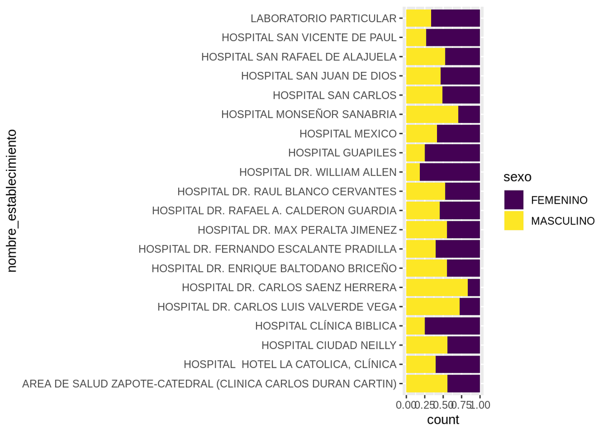

```r
# Hospital con mayor cantidad de casos
salud %>%
  group_by(nombre_establecimiento) %>%
  summarise(
    total = n()
  ) %>%
  arrange(desc(total)) %>%
  slice(1:20) %>%
  inner_join(salud, by = "nombre_establecimiento")  %>%
  ggplot(aes(x = nombre_establecimiento, fill = sexo)) +
  geom_bar(position = "fill") +
  scale_fill_viridis_d() +
  coord_flip()
```